# Gráficos de PRS

[**Página com arquivo do script em RMarkdown**](https://github.com/Lcstoshio/Lcstoshio.github.io/blob/main/Tutorial_graphPRS/Code.Rmd)

# **Modelo Gráfico da distribuição do Escore Poligênico de Risco (PRS)**

Com os dados exportados do PRSice, no arquivo “Nome_do_arquivo.best” conseguimos os valores do Escore Poligênico de Risco (PRS) para cada uma das amostras/ indivíduos no melhor p-threshold (Colunas: FamilyID, IndividualID, In_Regression, ScorePRS).

Para criação dos gráficos procurei alguns sites úteis com exemplos de density plots (pacote: ggplot2) e como personalizá-los:

**Density Plot no ggplot2:**  
Cookbook-r  
[STHDA](http://www.sthda.com/english/wiki/ggplot2-density-plot-quick-start-guide-r-software-and-data-visualization)

**Customizações (Cores e Detalhes):**  
[RColorBrewer](https://www.r-graph-gallery.com/38-rcolorbrewers-palettes.html)  
[Customizing Graphs](https://rkabacoff.github.io/datavis/Customizing.html)

**Arquivos necessários (toy data):**

- [**test.best:**](https://lcstoshio.github.io/Tutorial_graphPRS/test.best) exportado pelo PRSice (output.best) e contém os escores de risco para cada indivíduo no melhor p-threshold
- [**test.summary:**](https://lcstoshio.github.io/Tutorial_graphPRS/test.summary) exportado pelo PRSice (output.summary) e contém qual p-threshold foi utilizado, o número de SNPs, valor de p e R^2 do modelo, …
- [**test_pheno:**](https://lcstoshio.github.io/Tutorial_graphPRS/test_pheno) arquivo de fenótipos que foi utilizado no PRSice no comando –pheno

```r
# Pacotes utilizados
library (ggplot2) #graficos
library (plyr) #join_all, ddply
library (dplyr) #mutate
```

## **Importando e Manipulando Bancos de Dados**

Primeiro é necessário importar o arquivo exportado do PRSice “Nome_do_arquivo.best” e um outro arquivo que possui as informações de fenótipo e IDs dos indivíduos (mesmo arquivo que foi utilizado no PRSice para –pheno).

Para fenótipos qualitativos (ex.: caso/controle) é melhor utilizar gráficos de densidade, em casos de fenótipos quantitativos (ex.: altura) seria melhor utilizar um gráficos de dispersão (scatterplot).

Depois é necessário realizar algumas alterações nesses arquivos, para que possamos por fim juntá-los num único data.frame que será utilizado na plotagem dos gráficos no ggplot2.

```r
# Ler o arquivo .best
prs <- read.table ("./test.best", header=T)
# Quando for analisar mais de um fenótipo é importante mudarmos o nome das colunas do escore para diferenciá-los
colnames(prs) <- c("FID", "IID", "ln_Regression", "a_PRS")

# Importando arquivo do fenótipo
phenotype <- read.table ("./test_pheno", header = T)
colnames(phenotype) <- c("FID2", "IID", "pheno") # é bom mudar o nome da coluna FID pq da problema depois ter 2 colunas com mesmo nome
# Em casos de dados qualitativos é melhor alterar a nomenclatura do fenótipo (0 e 1 para controle/ caso)
phenotype <- mutate(phenotype, pheno=factor(pheno, labels=c('Controle', 'Caso')))

# Juntando o arquivo do escore e o arquivo do fenótipo (necessário que possuam uma coluna em comum "IID")
final <- join_all(list(prs, phenotype),by = "IID", type="inner") # inner = faz com que pegue IIDs que ambos arquivos possuem em comum
```

## **Gráficos (ggplot2)**

E por fim, utilizando o ggplot2 iremos criar os gráficos de densidade. Além disso, utilizei uma outra função extra que nos da a média do escore do PRS de cada grupo (Controle e Caso).

```r
# Cálculo da média dos escores que será traçada na curva de distribuição
mean <- ddply(final, "pheno", summarise, grp.mean=mean(a_PRS))
mean
```

```
##      pheno grp.mean
## 1 Controle      1.5
## 2     Caso      2.0
```

```r
# Contagem dos casos e controle
table(final$pheno)
```

```
##
## Controle     Caso
##       25       25
```

```r
# Também gosto de ter o .summary que mostra o threshold utilizado, mas é opcional
summary <- read.table ("./test.summary", header =T)
summary
```

```
##   Phenotype  Set Threshold   PRS.R2 Full.R2   Null.R2 Prevalence Coefficient
## 1      test Base         1 0.047464 0.10403 0.0593846          -     2112.46
##   Standard.Error          P Num_SNP
## 1        818.232 0.00983032    1801
```

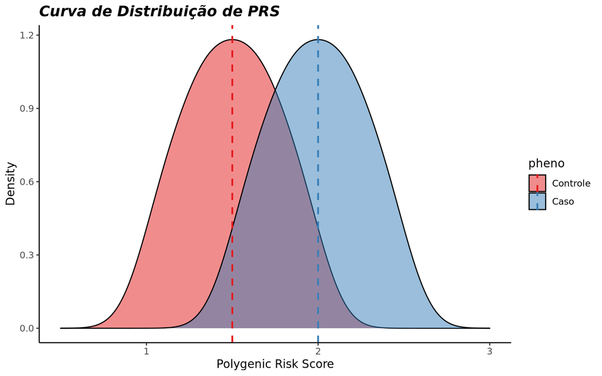

```r
ggplot(final, aes(x=a_PRS, group=pheno, fill=pheno))+ # a_PRS = escores; pheno = grupos
     geom_density(alpha=0.5)+ # alpha = densidade da cor
     geom_vline(data=mean, aes(xintercept=grp.mean, colour=pheno), linetype="dashed", size=0.8)+ # linha da média
     scale_fill_brewer(palette="Set1") + # Cor dos gráficos
     scale_color_brewer(palette="Set1") + # Cor das linhas da média
     theme_classic()+ # um dos temas para gráficos
     theme(plot.title = element_text(color="black", size=14, face="bold.italic"), legend.position = "right")+ # Fonte do título e posição da legenda
     ggtitle ("Curva de Distribuição de PRS")+ # Título
     labs(x="Polygenic Risk Score", y="Density")+ # Nome do eixo x e y
     xlim(0.5,3) # Limites do eixo x
```